# Neural networks in PyTorch

### Example python code from

### Deep Learning with PyTorch, Eli Stevens, Luca Antiga

#### PyTorch has the submodule torch.nn dedicated to neural networks

#### We can use the subclass Linear as a function...

```python
import torch.nn as nn

linear_model = nn.Linear(1, 1) # <1>
linear_model(t_un_val)
```

```
tensor([[2.0144],
        [2.2543]], grad_fn=<AddmmBackward>)
```

#### or as a model with a number of weights

```python
linear_model.weight
```

```
Parameter containing:
tensor([[0.2449]], requires_grad=True)
```

#### and biases.

```python
linear_model.bias
```

```
Parameter containing:
tensor([0.8291], requires_grad=True)
```

#### Modules in nn are written to produce outputs for a batch of multiple inputs at the same time. The zeroeth dimension of the input is the number of samples in the batch

#### This allows efficient parallel processing

#### Going back to the thermometer example

```python
linear_model = nn.Linear(1, 1) # <1>
optimizer = optim.SGD(
    linear_model.parameters(), # <2>
    lr=1e-2)
```

#### Note how you no longer have to define and create parameters, each module in nn will have its own list of parameters that can be passed to the optimizer.

```python
linear_model.parameters()
```

```
<generator object Module.parameters at 0x7fe9a3c2bc50>
```

```python
list(linear_model.parameters())
```

```
[Parameter containing:
 tensor([[-0.0065]], requires_grad=True), Parameter containing:
 tensor([0.8832], requires_grad=True)]
```

#### Note the requires_grad=True, which means a computation graph is build

#### The training loop now becomes

```python
def training_loop(n_epochs, optimizer, model, loss_fn, t_u_train, t_u_val, t_c_train, t_c_val):
    for epoch in range(1, n_epochs + 1):
        t_p_train = model(t_u_train) # <1>
        loss_train = loss_fn(t_p_train, t_c_train)

        t_p_val = model(t_u_val) # <1>
        loss_val = loss_fn(t_p_val, t_c_val)

        optimizer.zero_grad()
        loss_train.backward() # <2>
        optimizer.step()

        if epoch == 1 or epoch % 1000 == 0:
            print('Epoch {}, Training loss {}, Validation loss {}'.format(
                epoch, float(loss_train), float(loss_val)))
```

#### Note how parameters are no longer passed to the loop, model or loss but contained in the model

#### The nn module also comes with loss functions

#### One such is the MSELoss (MSE = Mean Squared Error)

#### Calling the training loop with Linear and MSELoss submodules from nn becomes

```python
linear_model = nn.Linear(1, 1)
optimizer = optim.SGD(linear_model.parameters(), lr=1e-2)

training_loop(
    n_epochs = 3000,
    optimizer = optimizer,
    model = linear_model,
    loss_fn = nn.MSELoss(), # <1>
    t_u_train = t_un_train,
    t_u_val = t_un_val,
    t_c_train = t_c_train,
    t_c_val = t_c_val)

print()
print(linear_model.weight)
print(linear_model.bias)
```

```
Epoch 1, Training loss 153.56851196289062, Validation loss 95.73174285888672
Epoch 1000, Training loss 3.0947422981262207, Validation loss 5.586836338043213
Epoch 2000, Training loss 2.624056100845337, Validation loss 4.677236557006836
Epoch 3000, Training loss 2.615919351577759, Validation loss 4.563891410827637

Parameter containing:
tensor([[5.3060]], requires_grad=True)
Parameter containing:
tensor([-16.8043], requires_grad=True)
```

#### Lets try a neural network instead of linear model

#### Here we have a linear function whos output is passed into tanh activation function and then again into a linear function.

```python
seq_model = nn.Sequential(
            nn.Linear(1, 13), # <1>
            nn.Tanh(),
            nn.Linear(13, 1)) # <2>
seq_model
```

```
Sequential(
  (0): Linear(in_features=1, out_features=13, bias=True)
  (1): Tanh()
  (2): Linear(in_features=13, out_features=1, bias=True)
)
```

#### Note the arbitrarily chosen number 13 at <1> and <2>. The idea is that we make the number of features large internally in the model and then compress them back down to a single output. In that way we can learn different aspects of the data that are relevant for the overall output.

```python
[param.shape for param in seq_model.parameters()]
```

```
[torch.Size([13, 1]), torch.Size([13]), torch.Size([1, 13]), torch.Size([1])]
```

#### Training our neural network model and using it to predict on our validation set

```python
optimizer = optim.SGD(seq_model.parameters(), lr=1e-3) # <1>

training_loop(
    n_epochs = 5000,
    optimizer = optimizer,
    model = seq_model,
    loss_fn = nn.MSELoss(),
    t_u_train = t_un_train,
    t_u_val = t_un_val,
    t_c_train = t_c_train,
    t_c_val = t_c_val)

print('output', seq_model(t_un_val))
print('answer', t_c_val)
```

```
Epoch 1, Training loss 1.6441324949264526, Validation loss 2.722811460494995
Epoch 1000, Training loss 1.6125497817993164, Validation loss 2.9127023220062256
Epoch 2000, Training loss 1.6076585054397583, Validation loss 2.9689078330993652
Epoch 3000, Training loss 1.6057016849517822, Validation loss 2.9995310306549072
Epoch 4000, Training loss 1.6046316623687744, Validation loss 3.014885187149048
Epoch 5000, Training loss 1.6038177013397217, Validation loss 3.020955801010132
output tensor([[ 7.6715],
        [13.1978]], grad_fn=<AddmmBackward>)
answer tensor([[ 6.],
        [15.]])
```

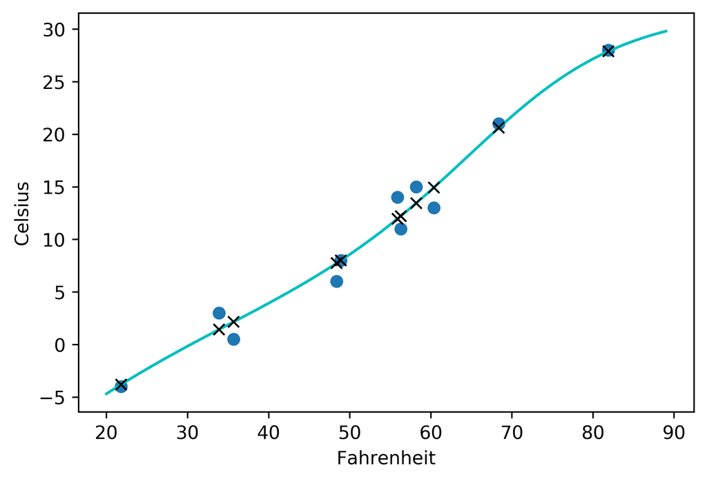

```python
from matplotlib import pyplot as plt

t_range = torch.arange(20., 90.).unsqueeze(1)

fig = plt.figure(dpi=600)
plt.xlabel("Fahrenheit")
plt.ylabel("Celsius")
plt.plot(t_u.numpy(), t_c.numpy(), 'o')
plt.plot(t_range.numpy(), seq_model(0.1 * t_range).detach().numpy(), 'c-')
plt.plot(t_u.numpy(), seq_model(0.1 * t_u).detach().numpy(), 'kx')
```

#### What if the model cannot be written as a sequential process, using nn.Sequential?

#### Answer: subclass the nn.Module

```python
class SubclassModel(nn.Module):
    def __init__(self):
        super().__init__()
        self.hidden_linear = nn.Linear(1, 13)
        self.hidden_activation = nn.Tanh()
        self.output_linear = nn.Linear(13, 1)

    def forward(self, input):
        hidden_t = self.hidden_linear(input)
        activated_t = self.hidden_activation(hidden_t)
        output_t = self.output_linear(activated_t)
        return output_t

subclass_model = SubclassModel()
subclass_model
```

```
SubclassModel(
  (hidden_linear): Linear(in_features=1, out_features=13, bias=True)
  (hidden_activation): Tanh()
  (output_linear): Linear(in_features=13, out_features=1, bias=True)
)
```